# The PROFOUND database

Ramiro Silveyra Gonzalez, Christopher Reyer, Mats Mahnken, Florian Hartig

2020-05-04

Abstract

This vignette provides an overview of the Profound database for benchmarking forest vegetation models, in particular database structure, content, data policy and an overview of each forest site contained in the database.

# Overview

The PROFOUND database (PROFOUND DB) brings together data from a wide range of data sources to evaluate vegetation models and simulate climate impacts at the forest stand scale. It includes 9 forest sites across Europe, and provides for them a site description as well as soil, climate, CO2, Nitrogen deposition, tree-level, forest stand-level and remote sensing data. Moreover, for a subset of 5 sites, also time series of carbon fluxes, energy balances and soil water are available.

For more details, see the [ProfoundData website](http://doi.org/10.5880/PIK.2020.006), as well as Reyer et al, The PROFOUND database for evaluating vegetation models and simulating climate impacts on forests, Earth Syst. Sci. Data Discuss., https://doi.org/10.5194/essd-2019-220, in review, 2019.

# Data Policy

The PROFOUND Database (DB) is available under the Creative Commons Attribution-NonCommercial 4.0 International license (CC BY-NC 4.0). Further data policy statements of the individual data sets contained in the PROFOUND database are listed in the table below.

Table 1: Additional data policy statements specific to the individual datasets included in the PROFOUND database.

| dataset | dataPolicy |
| --- | --- |
| CLIMATE_ISIMIP2B | Standard PROFOUND database policy |
| CLIMATE_ISIMIP2BLBC | Standard PROFOUND database policy |
| CLIMATE_ISIMIP2A | Standard PROFOUND database policy |
| CLIMATE_ISIMIPFT | Standard PROFOUND database policy |
| NDEPOSITION_EMEP | Please consider this data policy statement from EMEP: The Environment Agency - Austria allows the reproduction of its resources, with appropriate citation, for non-commercial purposes provided no othe… |
| NDEPOSITION_ISIMIP2B | Standard PROFOUND database policy |
| CO2_ISIMIP | Standard PROFOUND database policy |
| ENERGYBALANCE | Please consider this data policy statement from FLUXNET: This work used eddy covariance data acquired and shared by the FLUXNET community, including these networks: CarboEuropeIP, CarboItaly and ICOS.… |
| FLUX | Please consider this data policy statement from FLUXNET: This work used eddy covariance data acquired and shared by the FLUXNET community, including these networks: CarboEuropeIP, CarboItaly and ICOS.… |
| METEOROLOGICAL | Please consider this data policy statement from FLUXNET: This work used eddy covariance data acquired and shared by the FLUXNET community, including these networks: CarboEuropeIP, CarboItaly and ICOS.… |
| SOILTS | Please consider this data policy statement from FLUXNET: This work used eddy covariance data acquired and shared by the FLUXNET community, including these networks: CarboEuropeIP, CarboItaly and ICOS.… |
| MODIS_MOD09A1 | When using the data, please cite it as ORNL DAAC 2008 and include the following reference (ORNL DAAC 2008. MODIS Collection 5 Land Products Global Subsetting and Visualization Tool. ORNL DAAC, Oak Rid… |
| MODIS_MOD11A2 | When using the data, please cite it as ORNL DAAC 2008 and include the following reference (ORNL DAAC 2008. MODIS Collection 5 Land Products Global Subsetting and Visualization Tool. ORNL DAAC, Oak Rid… |
| MODIS_MOD13Q1 | When using the data, please cite it as ORNL DAAC 2008 and include the following reference (ORNL DAAC 2008. MODIS Collection 5 Land Products Global Subsetting and Visualization Tool. ORNL DAAC, Oak Rid… |
| MODIS_MOD15A2 | When using the data, please cite it as ORNL DAAC 2008 and include the following reference (ORNL DAAC 2008. MODIS Collection 5 Land Products Global Subsetting and Visualization Tool. ORNL DAAC, Oak Rid… |
| MODIS_MOD17A2 | When using the data, please cite it as ORNL DAAC 2008 and include the following reference (ORNL DAAC 2008. MODIS Collection 5 Land Products Global Subsetting and Visualization Tool. ORNL DAAC, Oak Rid… |
| TREE | See site specific policy |
| STAND | See site specific policy |
| SOIL | See site specific policy |
| CLIMATE_LOCAL | See site specific policy |

# Database structure

The PROFOUND database is a relational SQLite database and it is made of several independent tables (Fig. 1). From these tables views are created that can be accessed and downloaded by users with the ProfoundData package.

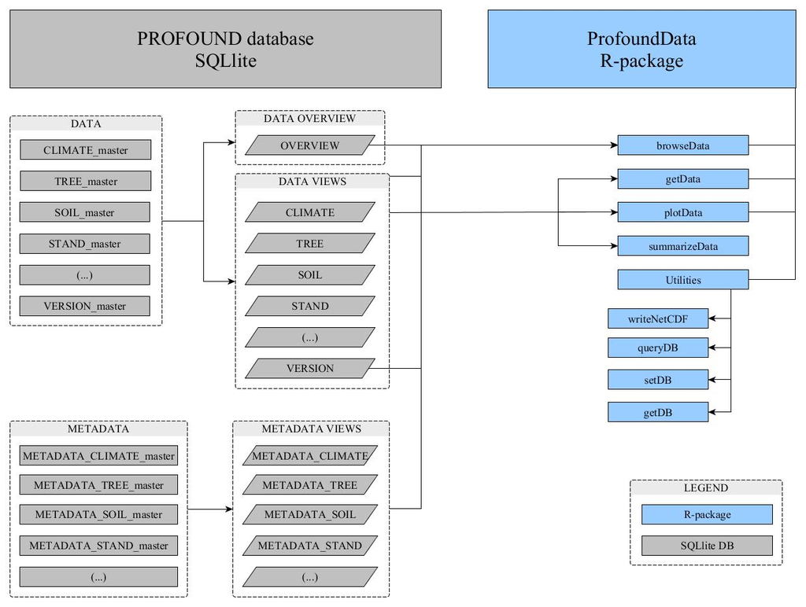

Figure 1: Overview on the PROFOUND database and the R package.

# Site overview

The PROFOUND database includes 9 forest sites. They are listed in the table below.

Table 2: Forest sites included in the database.

| site_id | site | lat | lon | epsg | country | aspect_deg | elevation_masl | slope_percent |
| --- | --- | --- | --- | --- | --- | --- | --- | --- |
| 3 | bily_kriz | 49.30 | 18.320 | 4326 | Czech Republic | 180.0 | 875 | 12.5 |
| 5 | collelongo | 41.85 | 13.588 | 4326 | Italy | 252.0 | 1560 | 10.0 |
| 12 | hyytiala | 61.85 | 24.295 | 4326 | Finland | 180.0 | 185 | 2.0 |
| 13 | kroof | 48.25 | 11.400 | 4326 | Germany | 1.8 | 502 | 2.1 |
| 14 | le_bray | 44.72 | -0.769 | 4326 | France | **–** | 61 | 0.0 |
| 16 | peitz | 51.92 | 14.350 | 4326 | Germany | **–** | 50 | 0.0 |
| 20 | solling_beech | 51.77 | 9.570 | 4326 | Germany | 225.0 | 504 | 1.0 |
| 21 | soro | 55.49 | 11.645 | 4326 | Denmark | **–** | 40 | 0.0 |
| 25 | solling_spruce | 51.77 | 9.580 | 4326 | Germany | 90.0 | 508 | 1.0 |

There is an overview table to provide the information on which data is available for each site. The table is created by combining all existing tables in the database.

Table 3: Overview of sites and datasets

| site_id | site | SITES | TREE | STAND | SOIL | CLIMATE_LOCAL | CLIMATE_ISIMIP2B | CLIMATE_ISIMIP2BLBC | CLIMATE_ISIMIP2A | CLIMATE_ISIMIPFT | METEOROLOGICAL | FLUX | ATMOSPHERICHEATCONDUCTION | SOILTS | NDEPOSITION_EMEP | NDEPOSITION_ISIMIP2B | CO2_ISIMIP | MODIS_MOD09A1 | MODIS_MOD15A2 | MODIS_MOD11A2 | MODIS_MOD13Q1 | MODIS_MOD17A2 | MODIS |
| --- | --- | --- | --- | --- | --- | --- | --- | --- | --- | --- | --- | --- | --- | --- | --- | --- | --- | --- | --- | --- | --- | --- | --- |
| 3 | bily_kriz | 1 | 1 | 1 | 1 | 1 | 1 | 1 | 1 | 1 | 1 | 1 | 1 | 1 | 1 | 1 | 1 | 1 | 1 | 1 | 1 | 1 | 1 |
| 5 | collelongo | 1 | 1 | 1 | 1 | 1 | 1 | 1 | 1 | 1 | 1 | 1 | 1 | 1 | 1 | 1 | 1 | 1 | 1 | 1 | 1 | 1 | 1 |
| 12 | hyytiala | 1 | 1 | 1 | 1 | 1 | 1 | 1 | 1 | 1 | 1 | 1 | 1 | 1 | 1 | 1 | 1 | 1 | 1 | 1 | 1 | 1 | 1 |
| 13 | kroof | 1 | 1 | 1 | 1 | 1 | 1 | 1 | 1 | 1 | 0 | 0 | 0 | 0 | 1 | 1 | 1 | 1 | 1 | 1 | 1 | 1 | 1 |
| 14 | le_bray | 1 | 0 | 1 | 1 | 1 | 1 | 1 | 1 | 1 | 1 | 1 | 1 | 1 | 1 | 1 | 1 | 1 | 1 | 1 | 1 | 1 | 1 |
| 16 | peitz | 1 | 1 | 1 | 1 | 1 | 1 | 1 | 1 | 1 | 0 | 0 | 0 | 0 | 1 | 1 | 1 | 1 | 1 | 1 | 1 | 1 | 1 |
| 20 | solling_beech | 1 | 1 | 1 | 1 | 1 | 1 | 1 | 1 | 1 | 0 | 0 | 0 | 0 | 1 | 1 | 1 | 1 | 1 | 1 | 1 | 1 | 1 |
| 21 | soro | 1 | 1 | 1 | 1 | 1 | 1 | 1 | 1 | 1 | 1 | 1 | 1 | 1 | 1 | 1 | 1 | 1 | 1 | 1 | 1 | 1 | 1 |
| 25 | solling_spruce | 1 | 1 | 1 | 1 | 1 | 1 | 1 | 1 | 1 | 0 | 0 | 0 | 0 | 1 | 1 | 1 | 1 | 1 | 1 | 1 | 1 | 1 |

# Datasets

## Dataset SITES

The sites parameters were provided by the local site data responsibles. The sites variables that we included in the database are listed in the table below.

Table 4: Description of SITES variables included in the database.

| variable | type | units | description |
| --- | --- | --- | --- |
| site | TEXT | adimensional | Site name |
| site2 | TEXT | adimensional | Additional site name |
| site_id | INTEGER | adimensional | Site code as decimal number (01-99) |
| aspect_deg | REAL | degree | Direction of slope inclination. Degrees against North. No Value indicates no exposition. |
| country | TEXT | adimensional | Country |
| elevation_masl | REAL | m | Elevation above sea level as recorded by PI |
| epsg | INTEGER | adimensional | EPSG Coordinate System |
| lat | REAL | degree decimal | Latitude |
| lon | REAL | degree decimal | Longitude |
| natVegetation_code1 | TEXT | adimensional | Code of the vegetation mapping unit group in the “Map of the Natural Vegetation of Europe”. BOHN, U.; GOLLUB, G. & HETTWER, C. (2000) Karte der natuerlichen Vegetation Europas. Massstab 1:2.500.000 Ka… |
| natVegetation_code2 | TEXT | adimensional | Code of the vegetation mapping unit in the “Map of the Natural Vegetation of Europe”. BOHN, U.; GOLLUB, G. & HETTWER, C. (2000) Karte der natuerlichen Vegetation Europas. Massstab 1:2.500.000 Karten u… |
| natVegetation_description | TEXT | adimensional | Description of natVegetation_code2. BOHN, U.; GOLLUB, G. & HETTWER, C. (2000) Karte der natuerlichen Vegetation Europas. Massstab 1:2.500.000 Karten und Legende. Teil 1-3.. Bundesamt fuer Naturschutz,… |
| slope_percent | REAL | percent | Mean slope within the plot |

## Dataset SITEDESCRIPTION

The sites description were provided by the local site data responsibles. The site description variables that we included in the database are listed in the table below.

Table 5: Description of SITEDESCRIPTION variables included in the database.

| variable | type | units | description |
| --- | --- | --- | --- |
| site | TEXT | adimensional | Site name |
| site_id | INTEGER | adimensional | Site code as decimal number (01-99) |
| description | TEXT | adimensional | Ecological description of the site |
| reference | TEXT | adimensional | Publications referring to the site description and the site datasets |

## Dataset TREE

The individual tree data were provided by the local site data responsibles. The tree variables that we included in the database are listed in the table below.

Table 6: Description of TREE variables included in the database.

| variable | type | units | description |
| --- | --- | --- | --- |
| record_id | INTEGER | adimensional | Record ID as decimal number |
| site | TEXT | adimensional | Site name |
| site_id | INTEGER | adimensional | Site code as decimal number (01-99) |
| species | TEXT | adimensional | Species name |
| species_id | TEXT | adimensional | Species text code |
| year | INTEGER | YYYY | Year with century as decimal number (0000-9999) |
| dbh1_cm | REAL | cm | Diameter at breast height |
| height1_m | REAL | m | Tree height |
| size_m2 | REAL | m2 | Plot size |

## Dataset STAND

The stand data were provided by the local site data responsibles. In some cases, the data were derived using the function *summarizeData* included in this package. The stand variables that we included in the database are listed in the table below.

Table 7: Description of STAND variables included in the database.

| variable | type | units | description |
| --- | --- | --- | --- |
| record_id | INTEGER | adimensional | Record ID as decimal number |
| site | TEXT | adimensional | Site name |
| site_id | INTEGER | adimensional | Site code as decimal number (01-99) |
| species | TEXT | adimensional | Species name |
| species_id | TEXT | adimensional | Species text code |
| year | INTEGER | YYYY | Year with century as decimal number (0000-9999) |
| aboveGroundBiomass_kgha | REAL | kg ha-1 | Above ground biomass |
| age | INTEGER | years | Mean stand age |
| ba_m2ha | REAL | m2 ha-1 | Basal area per hectare |
| branchesBiomass_kgha | REAL | kg ha-1 | Branches biomass |
| dbhArith_cm | REAL | cm | Arithmetic mean diameter |
| dbhBA_cm | REAL | cm | Average diameter weighted by basal area calculated as dbhBA = (ba1*dbh1 + ba2*dbh2 + … + bak*dbhk) / (ba1 + ba2+ … + bak), where bai and dbhi are the basal area and dbh, respectively, of the tree i, a… |
| dbhDQ_cm | REAL | cm | Mean squared diameter or quadratic mean diameter calculated as dbhDQ = sqrt( (dbh1<sup>2 + dbh2</sup>2+ … + dbhk^2) / N), where dbhi is the diameter at breat height of tree i, i = 1, 2, . . , k, N is … |
| density_treeha | REAL | tree ha-1 | Number of tree per ha |
| foliageBiomass_kgha | REAL | kg ha-1 | Foliage biomass |
| heightArith_m | REAL | m | Arithmetic mean height |
| heightBA_m | REAL | m | Average height weighted by basal area or Loreys height calculated as heightBA = (ba1*h1 + ba2*h2 + … + bak*hk) / (ba1 + ba2+ … + bak), where bai and hi are the basal area and height, respectively, of … |
| lai | REAL | adimensional | Leaf Area Index |
| rootBiomass_kgha | REAL | kg ha-1 | Root biomass |
| stemBiomass_kgha | REAL | kg ha-1 | Stem biomass |
| stumpCoarseRootBiomass_kgha | REAL | kg ha-1 | Stump and coarse roots biomass |

## Dataset SOIL

The soil data were provided by the local site data responsibles. The variables that we included in the database are listed in the table below. The data is very heteregenous, therefore not all variables are available for each site.

Table 8: Description of SOIL variables included in the database.

| variable | type | units | description |
| --- | --- | --- | --- |
| record_id | INTEGER | adimensional | Record ID as decimal number |
| site | TEXT | adimensional | Site name |
| site_id | INTEGER | adimensional | Site code as decimal number (1-99) |
| date | TEXT | adimensional | Unformatted date of inventory as provided for the inventory. See site specific metadata for further information on date. |
| bs_percent | REAL | percent | Percentage of alkaline and earth alkaline metals at CEC |
| cMax_percent | REAL | percent | Maximum soil carbon content |
| cMin_percent | REAL | percent | Minimum soil carbon content |
| cOrgSigma_percent | REAL | percent | Soil organic carbon content error estimate as standard deviation |
| cOrg_gcm3 | REAL | g cm-3 | Soil organic carbon content |
| cOrg_percent | REAL | percent | Soil organic carbon content |
| cSigma_kgm2 | REAL | kg m-2 | Soil carbon content error estimate as standard deviation |
| c_kgm2 | REAL | kg m-2 | Soil carbon content |
| c_percent | REAL | percent | Soil carbon content |
| cec_µeqg | REAL | µeq g-1 | Soil cation exchange capacity |
| claySigma_percent | REAL | percent | Soil clay particle content error estimate as standard deviation |
| clay_percent | REAL | percent | Soil clay particle content |
| cn | REAL | adimensional | Soil C:N ratio |
| densitySigma_gcm3 | REAL | g cm-3 | Soil bulk density content error estimate as standard deviation |
| density_gcm3 | REAL | g cm-3 | Soil bulk density |
| fcapv_percent | REAL | percent | Soil field capacity |
| fineRoot_percent | REAL | percent | Distribution of fine roots accross soil horizons |
| gravel_percent | REAL | percent | Soil gravel particle content |
| horizon | TEXT | adimensional | Name of soil horizon |
| humus_tCha | REAL | tC ha-1 | Humus carbon content |
| hydCondSat_cmd1 | REAL | cm d-1 | Soil hydraulic conductivity at saturation |
| layer_id | INTEGER | adimensional | Layer code as decimal number (1-99) |
| lowerDepth_cm | REAL | cm | Lower soil horizon limit |
| mbCSigma_mgg | REAL | mg C g-1 dry soil | Soil microbial biomass carbon error estimate as standard deviation |
| mbC_mgg | REAL | mg C g-1 dry soil | Soil microbial biomass carbon |
| mbNSigma_mgNg | REAL | mg N g-1 dry soil | Soil microbial biomass nitrogen error estimate as standard deviation |
| mbN_mgNg | REAL | mg N g-1 dry soil | Soil microbial biomass nitrogen |
| minRSigma_mgkgh | REAL | mg N kg-1 h-1 | Soil mineralisation rate error estimate as standard deviation |
| minR_mgkgh | REAL | mg N kg-1 h-1 | Soil mineralisation rate |
| nMax_percent | REAL | percent | Maximum soil nitrogen content |
| nMin_percent | REAL | percent | Minimum soil nitrogen content |
| nOrgSigma_percent | REAL | percent | Soil organic nitrogen content error estimate as standard deviation |
| nOrg_percent | REAL | percent | Soil organic nitrogen content |
| n_kgm2 | REAL | kg m-2 | Soil nitrogen content |
| n_percent | REAL | percent | Soil nitrogen content |
| ofhC_percent | REAL | percent | The organic fermentative-humic (Ofh) subhorizon consists of forest litter (leaves, bark, twigs etc) showing considerable decay. |
| ofhN_percent | REAL | percent | Carbon content in a gram of OFH sample |
| ofh_gDWm2 | REAL | g DW m-2 | Litter layer (leaves not decomposed) |
| ol_gDWm2 | REAL | g DW m-2 | Nitrogen content in a gram of OFH sample |
| phSigma_h2o | REAL | adimensional | Soil pH determined with H2O error estimate as standard deviation |
| phSigma_kcl | REAL | adimensional | Soil pH determined by KCl error estimate as standard deviation |
| ph_cacl2 | REAL | adimensional | Soil pH determined with CaCl2 |
| ph_h2o | REAL | adimensional | Soil pH determined with H2O |
| ph_kcl | REAL | adimensional | Soil pH deterimed with KCl |
| porosity_percent | REAL | percent | Soil water content at saturation in the bulk soil |
| rainGroundWater | REAL | adimensional | Whether the soil is mostly influenced by rain or ground water |
| sandSigma_percent | REAL | percent | Soil sand particle content error estimate as standard deviation |
| sand_percent | REAL | percent | Soil sand particle content |
| siltSigma_percent | REAL | percent | Soil silt particle content error estimate as standard deviation |
| silt_percent | REAL | percent | Soil silt particle content |
| table_id | INTEGER | adimensional | Table code as decimal number (1-99) |
| texture | TEXT | adimensional | Soil texture |
| thicknesSigma_cm | REAL | cm | Soil thickness error estimate |
| thickness_cm | REAL | cm | Soil thickness |
| type_fao | TEXT | adimensional | Soil type after ISSS-ISRIC-FAO (1998) World reference basis for soil resources. World Soil Resources Reports 84. FAO, Rome. 92 p. |
| type_ka5 | TEXT | adimensional | Soil type after AG Boden (2005) Bodenkundliche Kartieranleitung. Bundesanstalt für Geowissenschaften und Rohstoffe, Hannover |
| upperDepth_cm | REAL | cm | Upper soil horizon limit |
| whcSigma_mm | REAL | mm | Soil water holding capacity error estimate |
| whc_mm | REAL | mm | Soil water holding capacity |
| whcp_percent | REAL | percent | Water holding capacity for plant available water |
| wiltp_percent | REAL | percent | Soil wilting point |

## Dataset CLIMATE

The climate data contains daily measurements of the following variables: min, max and mean temperature, precipitation, relative humidity, air pressure, global radiation and wind speed.

Table 9: Description of CLIMATE variables included in the database.

| variable | type | units | description |
| --- | --- | --- | --- |
| record_id | INTEGER | adimensional | Record ID as decimal number |
| site | TEXT | adimensional | Site name |
| site_id | INTEGER | adimensional | Site code as decimal number (01-99) |
| date | TEXT | adimensional | Date in format YYYY-MM-DD |
| year | INTEGER | YYYY | Year with century as decimal number (0000-9999) |
| mo | INTEGER | MM | Month as decimal number (01-12) |
| day | INTEGER | DD | Day of the month as decimal number (01-31) |
| airpress_hPa | REAL | hPa | Mean daily air pressure |
| p_mm | REAL | mm | Total daily precipitation |
| rad_Jcm2 | REAL | J cm-2 | Total daily global radiation |
| relhum_percent | REAL | percent | Mean daily relative humidity |
| tmax_degC | REAL | degree Celsius | Maximum daily temperature |
| tmean_degC | REAL | degree Celsius | Mean daily temperature |
| tmin_degC | REAL | degree Celsius | Minimum daily temperature |
| wind_ms | REAL | m s-1 | Mean daily wind speed |

## Dataset CLIMATE_LOCAL

The CLIMATE LOCAL data refers to climate data measured at each forest site or meteorological stations close to the site of the forest site. For those forest sites for which the data has been derived from half-hourly [FLUXNET2015](http://fluxnet.fluxdata.org/) data, we also provide the original half-hourly data in the table METEOROLOGICAL.

When relative humidity was not part of the original data, we calculated it from the vapour pressure deficit and the daily temperatures as

$$relhum\_percent = (1 - VPD\_F / es)*100$$

where

$$es = (es(tmax\_degC) - es(tmin\_degC))/2$$

and

$$es(Ta) = 0.6108e^{(17.27*Ta)/ (Ta + 237.3)}$$
Besides the variables listed in Table 9, the CLIMATE_LOCAL dataset contains additional variables to indicate the data quality.

Table 10: Description of CLIMATE_LOCAL quality variables from FLUXNET included in the database.

| variable | type | units | description |
| --- | --- | --- | --- |
| site | TEXT | adimensional | Site name |
| airpress_qc | REAL | adimensional | fraction between 0-1; indicating percentage of measured and good quality gapfill half-hourly data used to create the daily value |
| p_qc | REAL | adimensional | fraction between 0-1; indicating percentage of measured and good quality gapfill half-hourly data used to create the daily value |
| rad_qc | REAL | adimensional | fraction between 0-1; indicating percentage of measured and good quality gapfill half-hourly data used to create the daily value |
| relhum_qc | REAL | adimensional | fraction between 0-1; indicating percentage of measured and good quality gapfill half-hourly data used to create the daily value |
| tmax_qc | REAL | adimensional | fraction between 0-1; indicating percentage of measured and good quality gapfill half-hourly data used to create the daily value |
| tmean_qc | REAL | adimensional | fraction between 0-1; indicating percentage of measured and good quality gapfill half-hourly data used to create the daily value |
| tmin_qc | REAL | adimensional | fraction between 0-1; indicating percentage of measured and good quality gapfill half-hourly data used to create the daily value |
| wind_qc | REAL | adimensional | fraction between 0-1; indicating percentage of measured and good quality gapfill half-hourly data used to create the daily value |

## Dataset CLIMATE_ISIMIP

There are several climatic datasets based on the Inter-Sectoral Impact Model Intercomparison Project (ISIMIP). For each forest site, we extracted the climate data from the corresponding gridcell in the ISIMIP data.

- **CLIMATE_ISIMIPFT:** Based on climate data described here: Warszawski, L., Frieler, K., Huber, V., Piontek, F., Serdeczny, O., Schewe, (2013) The Inter-Sectoral Impact Model Intercomparison Project (ISI-MIP), Proceedings of the National Academy of Sciences,111,9, 3228-3232. https://doi.org/10.1073/pnas.1312330110, https://www.isimip.org/gettingstarted/#input-data-bias-correction
- **CLIMATE_ISIMIP2A:** Based on climate data described here: https://www.isimip.org/gettingstarted/#input-data-bias-correction
- **CLIMATE_ISIMIP2B:** Based on climate data described here: Frieler K., R. Betts, E. Burke, P. Ciais, S. Denvil, D. Deryng, K. Ebi, T. Eddy, K. Emanuel, J. Elliott, E. Galbraith, S.N. Gosling, K. Halladay, F. Hattermann, T. Hickler, J. Hinkel, V. Huber, C. Jones, V. Krysanova, S. Lange, H.K. Lotze, H. Lotze-Campen, M. Mengel, I. Mouratiadou, H. Müller Schmied, S. Ostberg, F. Piontek, A. Popp, C.P.O. Reyer, J. Schewe, M. Stevanovic, T. Suzuki, K. Thonicke, H. Tian, D.P. Tittensor, R. Vautard, M. van Vliet, L. Warszawski, F. Zhao (accepted pending revisions) Assessing the impacts of 1.5°C global warming - simulation protocol of the Inter-Sectoral Impact Model Intercomparison Project (ISIMIP2b). Geoscientific Model Development (https://www.isimip.org/gettingstarted/#input-data-bias-correction)
- **CLIMATE_ISIMIP2BLBC:** Based on climate data described here: Frieler K, R Betts, E Burke, P Ciais, S Denvil, D Deryng, K Ebi, T Eddy, K Emanuel, J Elliott, E Galbraith, SN Gosling, K Halladay, F Hattermann, T Hickler, J Hinkel, V Huber, C Jones, V Krysanova, S Lange, HK Lotze, H Lotze-Campen, M Mengel, I Mouratiadou, H Müller Schmied, S Ostberg, F Piontek, A Popp, CPO Reyer, J Schewe, M Stevanovic, T Suzuki, K Thonicke, H Tian, DP Tittensor, R Vautard, M van Vliet, L Warszawski, F Zhao (accepted pending revisions) Assessing the impacts of 1.5°C global warming - simulation protocol of the Inter-Sectoral Impact Model Intercomparison Project (ISIMIP2b). Geoscientific Model Development, https://www.isimip.org/gettingstarted/#input-data-bias-correction

ISIMIP climatic datasets contain additionally one or both of the variables *forcingCondition* and *forcingDataset*.

Table 11: Description of CLIMATE_ISIMIP addtional variables included in the database.

| variable | type | units | description |
| --- | --- | --- | --- |
| site | TEXT | adimensional | Site name |
| forcingCondition | TEXT | adimensional | This category refers to the conditions underlying the climatic forcing, e.g. following historical CO2 time series, preindustrial picontrol runs or representative concentration pathways (rcp). |
| forcingDataset | TEXT | adimensional | This category refers to data taken from bias-corrected general circulation models (e.g. hadgem) or historical global meteorological forcing data based on bias-corrected reanalysis data (e.g. watch) |

## Dataset NDEPOSITION

The nitrogen deposition data contain annual measurements of the variables listed in the table below.

Table 12: Description of NDEPOSITION variables included in the database.

| variable | type | units | description |
| --- | --- | --- | --- |
| record_id | INTEGER | adimensional | Record ID as decimal number |
| site | TEXT | adimensional | Name of the site |
| site_id | INTEGER | adimensional | Site code as decimal number (01-99) |
| year | INTEGER | YYYY | Year with century as decimal number (0000-9999) |
| nhx_gm2 | REAL | g m-2 | Total deposition of reduced nitrogen (Dry+Wet RdN) |
| noy_gm2 | REAL | g m-2 | Total deposition of oxidized nitrogen (Dry+Wet oxN) |

## Dataset NDEPOSITION_EMEP

The NDEPOSITION_EMEP data were obtained from EMEP/CEIP 2014 Present state of emissions as used in EMEP models (http://www.ceip.at/webdab_emepdatabase/emissions_emepmodels/).

## Dataset NDEPOSITION_ISIMIP2B

The NDEPOSITION_EMEP data were extracted for for each forest site from the corresponding gridcell in the ISIMIP data described in Frieler K., R. Betts, E. Burke, P. Ciais, S. Denvil, D. Deryng, K. Ebi, T. Eddy, K. Emanuel, J. Elliott, E. Galbraith, S.N. Gosling, K. Halladay, F. Hattermann, T. Hickler, J. Hinkel, V. Huber, C. Jones, V. Krysanova, S. Lange, H.K. Lotze, H. Lotze-Campen, M. Mengel, I. Mouratiadou, H. Müller Schmied, S. Ostberg, F. Piontek, A. Popp, C.P.O. Reyer, J. Schewe, M. Stevanovic, T. Suzuki, K. Thonicke, H. Tian, D.P. Tittensor, R. Vautard, M. van Vliet, L. Warszawski, F. Zhao (accepted pending revisions) Assessing the impacts of 1.5°C global warming - simulation protocol of the Inter-Sectoral Impact Model Intercomparison Project (ISIMIP2b). Geoscientific Model Development (https://www.isimip.org/gettingstarted/#input-data-bias-correction). The dataset contains additionally the variable *forcingCondition*.

Table 13: Description of NDEPOSITION_ISIMIP2B addtional variables included in the database.

| variable | type | units | description | source |
| --- | --- | --- | --- | --- |
| forcingCondition | TEXT | adimensional | This category refers to the conditions underlying the climatic forcing, e.g. following historical CO2 time series, preindustrial picontrol runs or representative concentration pathways (rcp). | ISIMIP |

## Dataset CO2_ISIMIP

The CO2 dataset contains annual global concentrations of atmospheric CO2 for several forcing conditions.

Table 14: Description of CO2_ISIMIP variables included in the database.

| variable | type | units | description |
| --- | --- | --- | --- |
| record_id | INTEGER | adimensional | Record ID as decimal number |
| site | TEXT | adimensional | Site name |
| site_id | INTEGER | adimensional | Site code as decimal number (01-99) |
| forcingCondition | TEXT | adimensional | This category refers to the conditions underlying the climatic forcing, e.g. following historical CO2 time series or representative concentration pathways (rcp). |
| year | INTEGER | YYYY | Year with century as decimal number (0000-9999) |
| co2_ppm | REAL | ppm | CO2 mean global concentrations for the different different forcing conditions: RCP and historical values (1975-2013) |

## Dataset ATMOSPHERICHEATCONDUCTION

The ATMOSPHERICHEATCONDUCTION data contains half-hourly measurements of the variables listed in the table below and was obtained from [FLUXNET2015](http://fluxnet.fluxdata.org/) data.

Table 15: Description of ATMOSPHERICHEATCONDUCTION variables included in the database.

| variable | type | units | description |
| --- | --- | --- | --- |
| record_id | INTEGER | adimensional | Record ID as decimal number |
| site_id | INTEGER | adimensional | Site code as decimal number (01-99) |
| date | TEXT | adimensional | Date in format YYYY-MM-DD hh:mm:ss. Derived from TIMESTAMP_START |
| year | INTEGER | YYYY | Year with century as decimal number (0000-9999). Derived from TIMESTAMP_START |
| mo | INTEGER | MM | Month as decimal number (01-12). Derived from TIMESTAMP_START |
| day | INTEGER | DD | Day of the month as decimal number (01-31). Derived from TIMESTAMP_START |
| hCORRJOINTUNC_Wm2 | REAL | W m-2 | Joint uncertainty estimation for h as sqrt(hRANDUNC<sup>2 + ((hCORR75 - hCORR25) / 1.349)</sup>2) |
| hCORR_Wm2 | REAL | W m-2 | Sensible heat flux, corrected hFMDS by energy balance closure correction factor |
| hFMDS_Wm2 | REAL | W m-2 | Sensible heat flux, gapfilled using MDS method |
| hFMDS_qc | INTEGER | adimensional | Quality flag for hCORR. 0 = measured; 1 = good quality gapfill; 2 = medium; 3 = poor. |
| leCORRJOINTUNC_Wm2 | REAL | W m-2 | Joint uncertainty estimation for le |
| leCORR_Wm2 | REAL | W m-2 | Latent heat flux, corrected le_FMDS by energy balance closure correction factor |
| leFMDS_Wm2 | REAL | W m-2 | Latent heat flux, gapfilled using MDS method |
| leFMDS_qc | INTEGER | adimensional | Quality flag for leCORR. 0 = measured; 1 = good quality gapfill; 2 = medium; 3 = poor. |
| timestampEnd | TEXT | YYYYMMDDHHMM | ISO timestamp end of averaging period - short format |
| timestampStart | TEXT | YYYYMMDDHHMM | ISO timestamp start of averaging period - short format |

## Dataset FLUX

The FLUX data contains half-hourly measurements of the variables listed in the table below and was obtained from [FLUXNET2015](http://fluxnet.fluxdata.org/) data.

Table 16: Description of FLUX variables included in the database.

| variable | type | units | description |
| --- | --- | --- | --- |
| record_id | INTEGER | adimensional | Record ID as decimal number |
| site_id | INTEGER | adimensional | Site code as decimal number (01-99) |
| date | TEXT | adimensional | Date in format YYYY-MM-DD hh:mm:ss. Derived from TIMESTAMP_START |
| year | INTEGER | YYYY | Year with century as decimal number (0000-9999). Derived from TIMESTAMP_START |
| mo | INTEGER | MM | Month as decimal number (01-12). Derived from TIMESTAMP_START |
| day | INTEGER | DD | Day of the month as decimal number (01-31). Derived from TIMESTAMP_START |
| gppDtCutRef_umolCO2m2s1 | REAL | umolCO2 m-2 s-1 | Gross Primary Production, from Daytime partitioning method, reference selected from GPP versions using a model efficiency approach. Based on corresponding NEE_CUT_XX version |
| gppDtCutSe_umolCO2m2s1 | REAL | umolCO2 m-2 s-1 | Standard Error for Gross Primary Production, calculated as stdev(gppDtCut_XX) / sqrt(40). SE from 40 half-hourly gppDtCut_XX |
| gppDtVutRef_umolCO2m2s1 | REAL | umolCO2 m-2 s-1 | Gross Primary Production, from Daytime partitioning method, reference version selected from GPP versions using a model efficiency approach. Based on corresponding neeVut_XX version |
| gppDtVutSe_umolCO2m2s1 | REAL | umolCO2 m-2 s-1 | Standard Error for Gross Primary Production, calculated as stdev(gppDtVut_XX) / sqrt(40. SE from 40 half-hourly gppDtVut_XX |
| gppNtCutRef_umolCO2m2s1 | REAL | umolCO2 m-2 s-1 | Gross Primary Production, from Nighttime partitioning method, reference selected from GPP versions using a model efficiency approach. Based on corresponding NEE_CUT_XX version |
| gppNtCutSe_umolCO2m2s1 | REAL | umolCO2 m-2 s-1 | Standard Error for Gross Primary Production, calculated as stdev(gppNtCut_XX) / sqrt(40). SE from 40 half-hourly gppNtCut_XX |
| gppNtVutRef_umolCO2m2s1 | REAL | umolCO2 m-2 s-1 | Gross Primary Production, from Nighttime partitioning method, reference version selected from GPP versions using a model efficiency approach. Based on corresponding neeVut_XX version |
| gppNtVutSe_umolCO2m2s1 | REAL | umolCO2 m-2 s-1 | Standard Error for Gross Primary Production, calculated as (stdev(gppNtVut_XX) / sqrt(40)). SE from 40 half-hourly gppNtVut_XX |
| neeCutRefJointunc_umolCO2m2s1 | REAL | umolCO2 m-2 s-1 | Joint uncertainty estimation for neeCutRef, including random uncertainty and USTAR filtering uncertainty [sqrt(neeCutRef_RANDUNC<sup>2 + ((NEE_CUT_84 - NEE_CUT_16) / 2)</sup>2)] for each half-hour |
| neeCutRef_qc | INTEGER | adimensional | Quality flag for neeCutRef. 0 = measured; 1 = good quality gapfill; 2 = medium; 3 = poor. |
| neeCutRef_umolCO2m2s1 | REAL | umolCO2 m-2 s-1 | Net Ecosystem Exchange, using Constant Ustar Threshold (CUT) across years, reference selected on the basis of the model efficiency |
| neeVutRefJointunc_umolCO2m2s1 | REAL | umolCO2 m-2 s-1 | Joint uncertainty estimation for neeVutRef, including random uncertainty and USTAR filtering uncertainty [sqrt(neeVutRef_RANDUNC<sup>2 + ((neeVut_84 - neeVut_16) / 2)</sup>2)] for each half-hour |
| neeVutRef_qc | INTEGER | adimensional | Quality flag for neeVutRef. 0 = measured; 1 = good quality gapfill; 2 = medium; 3 = poor. |
| neeVutRef_umolCO2m2s1 | REAL | umolCO2 m-2 s-1 | Net Ecosystem Exchange, using Variable Ustar Threshold (VUT) for each year, reference selected on the basis of the model efficiency |
| recoDtCutRef_umolCO2m2s1 | REAL | umolCO2 m-2 s-1 | Ecosystem Respiration, from Daytime partitioning method, reference selected from RECO versions using a model efficiency approach. Based on corresponding NEE_CUT_XX version |
| recoDtCutSe_umolCO2m2s1 | REAL | umolCO2 m-2 s-1 | Standard Error for Ecosystem Respiration, calculated as stdev(recoDtCut_XX) / sqrt(40). SE from 40 half-hourly recoDtCut_XX |
| recoDtVutRef_umolCO2m2s1 | REAL | umolCO2 m-2 s-1 | Ecosystem Respiration, from Daytime partitioning method, reference selected from RECO versions using a model efficiency approach. Based on corresponding neeVut_XX version |
| recoDtVutSe_umolCO2m2s1 | REAL | umolCO2 m-2 s-1 | Standard Error for Ecosystem Respiration, calculated as stdev(recoDtVut_XX) / sqrt(40). SE from 40 half-hourly recoDtCut_XX |
| recoNtCutRef_umolCO2m2s1 | REAL | umolCO2 m-2 s-1 | Ecosystem Respiration, from Nighttime partitioning method, reference selected from RECO versions using a model efficiency approach. Based on corresponding NEE_CUT_XX version |
| recoNtCutSe_umolCO2m2s1 | REAL | umolCO2 m-2 s-1 | Standard Error for Ecosystem Respiration, calculated as stdev(recoNtCut_XX) / sqrt(40. SE from 40 half-hourly recoNtCut_XX |
| recoNtVutRef_umolCO2m2s1 | REAL | umolCO2 m-2 s-1 | Ecosystem Respiration, from Nighttime partitioning method, reference selected from RECO versions using a model efficiency approach. Based on corresponding neeVut_XX version |
| recoNtVutSe_umolCO2m2s1 | REAL | umolCO2 m-2 s-1 | Standard Error for Ecosystem Respiration, calculated as stdev(recoNtVut_XX) / sqrt(40. SE from 40 half-hourly recoNtCut_XX |
| timestampEnd | TEXT | YYYYMMDDHHMM | ISO timestamp end of averaging period - short format |
| timestampStart | TEXT | YYYYMMDDHHMM | ISO timestamp start of averaging period - short format |

## Dataset METEOROLOGICAL

The METEOROLOGICAL data contains half-hourly measurements of the variables listed in the table below and was obtained from [FLUXNET2015](http://fluxnet.fluxdata.org/) data.

Table 17: Description of METEOROLOGICAL variables included in the database.

| variable | type | units | description |
| --- | --- | --- | --- |
| record_id | INTEGER | adimensional | Record ID as decimal number |
| site_id | INTEGER | adimensional | Site code as decimal number (01-99) |
| date | TEXT | adimensional | Date in format YYYY-MM-DD hh:mm:ss. Derived from TIMESTAMP_START |
| year | INTEGER | YYYY | Year with century as decimal number (0000-9999). Derived from TIMESTAMP_START |
| mo | INTEGER | MM | Month as decimal number (01-12). Derived from TIMESTAMP_START |
| day | INTEGER | DD | Day of the month as decimal number (01-31). Derived from TIMESTAMP_START |
| timestampEnd | TEXT | YYYYMMDDHHMM | ISO timestamp end of averaging period - short format |
| timestampStart | TEXT | YYYYMMDDHHMM | ISO timestamp start of averaging period - short format |
| lwInFMDS_Wm2 | REAL | W m-2 | Longwave radiation, incoming, gapfilled using MDS |
| lwInFMDS_qc | REAL | adimensional | Quality flag for lwInFMDS. 0 = measured; 1 = good quality gapfill; 2 = medium; 3 = poor. |
| lwInF_Wm2 | REAL | W m-2 | Longwave radiation, incoming, consolidated from lwInFMDS and lwInERA. lwInFMDS used if lwInFMDS_qc is 0 or 1. |
| lwInF_qc | INTEGER | adimensional | Quality flag for lwInF. 0 = measured; 1 = good quality gapfill; 2 = downscaled from ERA |
| pF_mm | REAL | mm | Precipitation consolidated from p and pERA |
| pF_qc | INTEGER | adimensional | Quality flag for pF. 0 = measured; 2 = downscaled from ERA |
| p_mm | REAL | mm | Precipitation. |
| paF_kPa | REAL | kPa | Atmospheric pressure consolidated from pa and paERA |
| paF_qc | INTEGER | adimensional | Quality flag for paF. 0 = measured; 2 = downscaled from ERA. |
| pa_kPa | REAL | kPa | Atmospheric pressure |
| swInFMDS_Wm2 | REAL | W m-2 | Shortwave radiation, incoming, gapfilled using MDS (negative values set to zero, e.g., negative values from instrumentation noise). |
| swInFMDS_qc | REAL | adimensional | Quality flag for swInFMDS. 0 = measured; 1 = good quality gapfill; 2 = medium; 3 = poor. |
| swInF_Wm2 | REAL | W m-2 | Shortwave radiation, incoming consolidated from swInFMDS and swInERA (negative values set to zero). swInFMDS used if swInFMDS_QC is 0 or 1 |
| swInF_qc | INTEGER | adimensional | Quality flag for swInF. 0 = measured; 1 = good quality gapfill; 2 = downscaled from ERA |
| taFMDS_degC | REAL | degree Celsius | Air temperature, gapfilled using MDS method |
| taFMDS_qc | INTEGER | adimensional | Quality flag for taFMDS. 0 = measured; 1 = good quality gapfill; 2 = medium; 3 = poor. |
| taF_degC | REAL | degree Celsius | Air temperature, consolidated from taFMDS and taERA |
| taF_qc | INTEGER | adimensional | Quality flag for taF. 0 = measured; 1 = good quality gapfill; 2 = downscaled from ERA. |
| vpdFMDS_hPa | REAL | hPa | Vapor Pressure Deficit, gapfilled using MDS. |
| vpdFMDS_qc | INTEGER | adimensional | Quality flag for vpdFMDS. 0 = measured; 1 = good quality gapfill; 2 = medium; 3 = poor. |
| vpdF_hPa | REAL | hPa | Vapor Pressure Deficit consolidated from vpdFMDS and vpdERA. vpdFMDS used if vpdFMDS_qc is 0 or 1. |
| vpdF_qc | INTEGER | adimensional | Quality flag for vpdF. 0 = measured; 1 = good quality gapfill; 2 = downscaled from ERA |
| wsF_ms1 | REAL | m s-1 | Wind speed, consolidated from ws and wsERA. ws used if measured. |
| wsF_qc | INTEGER | adimensional | Quality flag of wsF.0 = measured; 2 = downscaled from ERA. |
| ws_ms1 | REAL | m s-1 | Wind speed |

## Dataset SOILTS

The soil time series data contains half-hourly measurements of the variables listed in the table below and was obtained from [FLUXNET2015](http://fluxnet.fluxdata.org/) data.

Table 18: Description of SOILTS variables included in the database.

| variable | type | units | description |
| --- | --- | --- | --- |
| record_id | INTEGER | adimensional | Record ID as decimal number |
| site_id | INTEGER | adimensional | Site code as decimal number (01-99) |
| date | TEXT | adimensional | Date in format YYYY-MM-DD hh:mm:ss. Derived from TIMESTAMP_START |
| year | INTEGER | YYYY | Year with century as decimal number (0000-9999). Derived from TIMESTAMP_START |
| mo | INTEGER | MM | Month as decimal number (01-12). Derived from TIMESTAMP_START |
| day | INTEGER | DD | Day of the month as decimal number (01-31). Derived from TIMESTAMP_START |
| timestampEnd | TEXT | YYYYMMDDHHMM | ISO timestamp end of averaging period - short format |
| timestampStart | TEXT | YYYYMMDDHHMM | ISO timestamp start of averaging period - short format |
| swcFMDS1_degC | REAL | percent | Soil water content, gapfilled with MDS (numeric index “#” increases with the depth, 1 is shallowest) |
| swcFMDS1_qc | INTEGER | adimensional | Quality flag for tsFMDS#. 0 = measured; 1 = good quality gapfill; 2 = medium; 3 = poor. |
| swcFMDS2_degC | REAL | percent | Soil water content, gapfilled with MDS (numeric index “#” increases with the depth, 1 is shallowest) |
| swcFMDS2_qc | INTEGER | adimensional | Quality flag for tsFMDS#. 0 = measured; 1 = good quality gapfill; 2 = medium; 3 = poor. |
| swcFMDS3_degC | REAL | percent | Soil water content, gapfilled with MDS (numeric index “#” increases with the depth, 1 is shallowest) |
| swcFMDS3_qc | INTEGER | adimensional | Quality flag for tsFMDS#. 0 = measured; 1 = good quality gapfill; 2 = medium; 3 = poor. |
| swcFMDS4_degC | REAL | percent | Soil water content, gapfilled with MDS (numeric index “#” increases with the depth, 1 is shallowest) |
| swcFMDS4_qc | INTEGER | adimensional | Quality flag for tsFMDS#. 0 = measured; 1 = good quality gapfill; 2 = medium; 3 = poor. |
| swcFMDS5_degC | REAL | percent | Soil water content, gapfilled with MDS (numeric index “#” increases with the depth, 1 is shallowest) |
| swcFMDS5_qc | INTEGER | adimensional | Quality flag for tsFMDS#. 0 = measured; 1 = good quality gapfill; 2 = medium; 3 = poor. |
| tsFMDS1_degC | REAL | degree Celsius | Soil temperature, gapfilled with MDS (numeric index “#” increases with the depth, 1 is shallowest) |
| tsFMDS1_qc | INTEGER | adimensional | Quality flag for tsFMDS#. 0 = measured; 1 = good quality gapfill; 2 = medium; 3 = poor. |
| tsFMDS2_degC | REAL | degree Celsius | Soil temperature, gapfilled with MDS (numeric index “#” increases with the depth, 1 is shallowest) |
| tsFMDS2_qc | INTEGER | adimensional | Quality flag for tsFMDS#. 0 = measured; 1 = good quality gapfill; 2 = medium; 3 = poor. |
| tsFMDS3_degC | REAL | degree Celsius | Soil temperature, gapfilled with MDS (numeric index “#” increases with the depth, 1 is shallowest) |
| tsFMDS3_qc | INTEGER | adimensional | Quality flag for tsFMDS#. 0 = measured; 1 = good quality gapfill; 2 = medium; 3 = poor. |
| tsFMDS4_degC | REAL | degree Celsius | Soil temperature, gapfilled with MDS (numeric index “#” increases with the depth, 1 is shallowest) |
| tsFMDS4_qc | INTEGER | adimensional | Quality flag for tsFMDS#. 0 = measured; 1 = good quality gapfill; 2 = medium; 3 = poor. |
| tsFMDS5_degC | REAL | degree Celsius | Soil temperature, gapfilled with MDS (numeric index “#” increases with the depth, 1 is shallowest) |
| tsFMDS5_qc | INTEGER | adimensional | Quality flag for tsFMDS#. 0 = measured; 1 = good quality gapfill; 2 = medium; 3 = poor. |

## Dataset MODIS

The original MODIS time series are available at the [NASA Land Processes Distributed Archive Center (LP DAAC)](https://lpdaac.usgs.gov/). The data were downloaded from the [Land Product Subset web service](https://daac.ornl.gov/MODIS/) of the [Oak Ridge National Laboratory Distributed Active Archive Center (ORNL DAAC)](https://daac.ornl.gov/). Five different datasets are included in the database:

- **MODIS_MOD09A1**
- **MODIS_MOD15A2**
- **MODIS_MOD11A2**
- **MODIS_MOD13Q1**
- **MODIS_MOD17A2**

The data comprise surface reflectance, land surface temperature, vegetation indexes, Leaf Area Index (LAI) and Fraction of Photosynthetically Active Radiation (FPAR), GPP and Net Photosynthesis. The MODIS variables are listed the table below.

Table 19: Description of MODIS variables included in the database.

| variable | type | units | description | source |
| --- | --- | --- | --- | --- |
| record_id | INTEGER | adimensional | Record ID as decimal number | MOD09A1 |
| site | TEXT | adimensional | Site name | MOD09A1 |
| site_id | INTEGER | adimensional | Site code as decimal number (01-99) | MOD09A1 |
| date | TEXT | adimensional | Date in format YYYY-MM-DD | MOD09A1 |
| year | INTEGER | YYYY | Year with century as decimal number (0000-9999) | MOD09A1 |
| mo | INTEGER | MM | Month as decimal number (01-12) | MOD09A1 |
| day | INTEGER | DD | Day of the month as decimal number (01-31) | MOD09A1 |
| aB01_rad | REAL | radian | Angle in red. Spatial resolution: 0.5 km. Temporal resolution: 8-day composite. | MOD09A1 |
| aB02_rad | REAL | radian | Angle in near infrared. Calculated with MOD09A1. Spatial resolution 0.5 km | MOD09A1 |
| aB05_rad | REAL | radian | Angle in SWIR 1.Spatial resolution: 0.5 km. Temporal resolution: 8-day composite. | MOD09A1 |
| aB06_rad | REAL | radian | Angle in SWIR 2. Spatial resolution: 0.5 km. Temporal resolution: 8-day composite. | MOD09A1 |
| evi8 | REAL | adimensional | Enhance Vegetation Index. Spatial resolution: 0.5 km. Temporal resolution: 8-day composite | MOD09A1 |
| ndvi8 | REAL | adimensional | Normalized Difference Vegetation Index. Spatial resolution: 0.5 km. Temporal resolution: 8-day composite | MOD09A1 |
| ndwi | REAL | adimensional | Normalized Difference Water Index. Spatial resolution: 0.5 km. Temporal resolution: 8-day composite | MOD09A1 |
| reflB01_percent | REAL | percent reflectance | Surface Reflectance Band 1 (620–670 nm) Red. Fill value: NA. Spatial resolution: 0.5 km. Temporal resolution: 8-day composite. | MOD09A1 |
| reflB02_percent | REAL | percent reflectance | Surface Reflectance Band 2 (841–876 nm) NIR. Fill value: NA. Spatial resolution: 0.5 km. Temporal resolution: 8-day composite. | MOD09A1 |
| reflB03_percent | REAL | percent reflectance | Surface Reflectance Band 3 (459–479 nm) Blue. Fill value: NA. Spatial resolution: 0.5 km. Temporal resolution: 8-day composite. | MOD09A1 |
| reflB04_percent | REAL | percent reflectance | Surface Reflectance Band 4 (545–565 nm) Green. Fill value: NA. Spatial resolution: 0.5 km. Temporal resolution: 8-day composite. | MOD09A1 |
| reflB05_percent | REAL | percent reflectance | Surface Reflectance Band 5 (1230–1250 nm) SWIR1. Fill value: NA. Spatial resolution: 0.5 km. Temporal resolution: 8-day composite. | MOD09A1 |
| reflB06_percent | REAL | percent reflectance | Surface Reflectance Band 6 (1628–1652 nm) SWIR2. Fill value: NA. Spatial resolution: 0.5 km. Temporal resolution: 8-day composite. | MOD09A1 |
| reflB07_percent | REAL | percent reflectance | Surface Reflectance Band 7 (2105–2155 nm) SWIR3. Fill value: NA. Spatial resolution: 0.5 km. Temporal resolution: 8-day composite. | MOD09A1 |
| refl_qc | INTEGER | adimensional | Indicates the level of quality correction of the product (the seven bands) that is classified as follows: 0 = Highest quality, corrected product produced at ideal quality all bands; 2 = corrected prod… | MOD09A1 |
| sani_rad | REAL | radian | Shortwave Angle Normalized Index. Valid range: -3.14 - 3.14. Spatial resolution: 0.5 km. Temporal resolution: 8-day composite. | MOD09A1 |
| sasi_rad | REAL | radian | Shortwave Angle Slope Index. Spatial resolution: 0.5 km. Temporal resolution: 8-day composite | MOD09A1 |
| record_id | INTEGER | adimensional | Record ID as decimal number | MOD15A2 |
| site | TEXT | adimensional | Site name | MOD15A2 |
| site_id | INTEGER | adimensional | Site code as decimal number (01-99) | MOD15A2 |
| date | TEXT | adimensional | Date in format YYYY-MM-DD | MOD15A2 |
| year | INTEGER | YYYY | Year with century as decimal number (0000-9999) | MOD15A2 |
| mo | INTEGER | MM | Month as decimal number (01-12) | MOD15A2 |
| day | INTEGER | DD | Day of the month as decimal number (01-31) | MOD15A2 |
| fpar | REAL | adimensional | Proportion of available radiation in the photosynthetically active wavelengths. Valid range: 0 - 1. Fill value: NA. Spatial resolution: 1 km. Temporal resolution: 8-day composite. | MOD15A2 |
| fpar_qc | INTEGER | adimensional | Indicates the level of the product quality that is classified as follows: 0 = Good quality (main algorithm with or without saturation); 2 = Other quality (back-up algorithm or fill values) | MOD15A2 |
| lai | REAL | adimensional | Leaf area index. Valid range: 0 - 10. Fill value: NA. Spatial resolution: 1 km. Temporal resolution: 8-day composite. | MOD15A2 |
| lai_qc | INTEGER | adimensional | Indicates the level of the product quality that is classified as follows: 0 = Good quality (main algorithm with or without saturation); 2 = Other quality (back-up algorithm or fill values) | MOD15A2 |
| record_id | INTEGER | adimensional | Record ID as decimal number | MOD11A2 |
| site | TEXT | adimensional | Site name | MOD11A2 |
| site_id | INTEGER | adimensional | Site code as decimal number (01-99) | MOD11A2 |
| date | TEXT | adimensional | Date in format YYYY-MM-DD | MOD11A2 |
| year | INTEGER | YYYY | Year with century as decimal number (0000-9999) | MOD11A2 |
| mo | INTEGER | MM | Month as decimal number (01-12) | MOD11A2 |
| day | INTEGER | DD | Day of the month as decimal number (01-31) | MOD11A2 |
| lstDay_degK | REAL | degree Kelvin | Daytime land surface temperature. Valid range: 150 – 1310.7. Fill value: NA. Spatial resolution: 1 km. Temporal resolution: 8-day composite. | MOD11A2 |
| lstDay_qc | INTEGER | adimensional | Indicates the level of quality of the product that is classified as follows: 0 = good quality; 2 = other quality; 3 = interpolated, 4 = pixel not produced (NA) | MOD11A2 |
| lstNight_degK | REAL | degree Kelvin | Nighttime land surface temperature. Valid range: 150 – 1310.7. Fill value: NA. Spatial resolution: 1 km. Temporal resolution: 8-day composite. | MOD11A2 |
| lstNight_qc | INTEGER | adimensional | Indicates the level of quality of the product that is classified as follows: 0 = good quality; 2 = other quality; 3 = interpolated, 4 = pixel not produced (NA) | MOD11A2 |
| record_id | INTEGER | adimensional | Record ID as decimal number | MOD13Q1 |
| site | TEXT | adimensional | Site name | MOD13Q1 |
| site_id | INTEGER | adimensional | Site code as decimal number (01-99) | MOD13Q1 |
| date | TEXT | adimensional | Date in format YYYY-MM-DD | MOD13Q1 |
| year | INTEGER | YYYY | Year with century as decimal number (0000-9999) | MOD13Q1 |
| mo | INTEGER | MM | Month as decimal number (01-12) | MOD13Q1 |
| day | INTEGER | DD | Day of the month as decimal number (01-31) | MOD13Q1 |
| evi16 | REAL | adimensional | Enhanced Vegetation Index. Valid range: -0.2 - 1. Fill value: NA. Spatial resolution: 250 meters. Temporal resolution: 16-day composite. | MOD13Q1 |
| evi16_qc | REAL | adimensional | Indicates the level of the product quality that is classified as follows: 0 = good quality, index produced; 2 = other quality, index produced, but check other qc and index produced, but most probably … | MOD13Q1 |
| ndvi16 | REAL | adimensional | Normalized Difference Vegetation Index. Valid range: -0.2 - 1. Fill value: NA. Spatial resolution: 250 meters. Temporal resolution: 16-day composite. | MOD13Q1 |
| ndvi16_qc | REAL | adimensional | Indicates the level of the product quality that is classified as follows: 0 = good quality, index produced; 2 = other quality, index produced, but check other qc and index produced, but most probably … | MOD13Q1 |
| record_id | INTEGER | adimensional | Record ID as decimal number | MOD17A2 |
| site | TEXT | adimensional | Site name | MOD17A2 |
| site_id | INTEGER | adimensional | Site code as decimal number (01-99) | MOD17A2 |
| date | TEXT | adimensional | Date in format YYYY-MM-DD | MOD17A2 |
| year | INTEGER | YYYY | Year with century as decimal number (0000-9999) | MOD17A2 |
| mo | INTEGER | MM | Month as decimal number (01-12) | MOD17A2 |
| day | INTEGER | DD | Day of the month as decimal number (01-31) | MOD17A2 |
| gpp_gCm2d | REAL | gC m-2 d-1 | Gross Primary Production. Valid range: -375 – 375. Fill value: NA. Spatial resolution 1 km. Temporal resolution: 8-day accumulation. | MOD17A2 |
| gpp_qc | INTEGER | adimensional | Indicates the level of the product quality that is classified as follows: 0 = good quality, the estimates were done using the main algorithm with or without saturation; 2 = other quality, the estimate… | MOD17A2 |
| psNet_gCm2d | REAL | gC m-2 d-1 | Net Photosynthesis (GPP – maintenance respiration). Valid range: -375 – 375. Fill value: NA. Spatial resolution 1 km. Temporal resolution: 8-day accumulation. | MOD17A2 |
| psNet_qc | INTEGER | adimensional | Indicates the level of the product quality that is classified as follows: 0 = good quality, the estimates were done using the main algorithm with or without saturation; 2 = other quality, the estimate… | MOD17A2 |